# Structural topic models for enriching quantitative text analysis material available at https://github.com/cbpuschmann/stm_ic2s2

Cornelius Puschmann & Carsten Schwemmer

July 17, 2019

*A huge thanks to Brandon Stewart for maintaining the STM package and for providing some of the content which we use in this tutorial.*

# Setup

## Prepare your R environment

- Download and extract the tutorial content from our [github repository](https://github.com/cbpuschmann/stm_ic2s2)
- Open the R project file `stm_ic2s2.Rproj` in RStudio

## How R Markdown files work

- Code is placed inside code cells, documentation is placed outside of code cells.
- Create new code chunks with CTRL/CMD + ALT + I
- Use CTRL/CMD + SHIFT + ENTER to run entire code cell
- Use CTRL/CMD + ENTER to run selected code

```r
# this is a  comment inside a code cell
2+3
```

```
## [1] 5
```

```r
5+2
```

```
## [1] 7
```

## Install packages

- Please install the packages that we will need for the tutorial:

```r
install.packages(c('tidyverse', 'stm', 'stminsights',
                   'quanteda', 'rmarkdown'),
                 dependencies = TRUE)
```

## Loading data and packages

```r
library(tidyverse)
library(stm)
library(stminsights)
library(quanteda)
library(lubridate)
theme_set(theme_light())
df <- read_csv('data/donors_choose_sample.csv')
```

## The data we use for the workshop

- We will be using a sample from a [Kaggle](https://www.kaggle.com/c/donorschoose-application-screening) Data Science for Good challenge
- DonorsChoose.org provided the data and hosts an online platform where teachers can post requests for resources and people can make donations to these projects
- The goal of the original challenge was to match previous donors with campaigns that would most likely inspire additional donations
- The dataset includes texts and context information which might help answer various questions in social science. A description of variables is available [here](https://www.kaggle.com/donorschoose/io/discussion/56030)

## What could we learn from this data?

Examples of questions we might ask:

- How has classroom technology use changed over time? How does it differ by geographic location and the age of students?
- How do the requests of schools in urban areas compare to those in rural areas?
- What predicts whether a project will be funded?
- How do the predictors of funding vary by geographic location? Or by economic status of the students?
- Do male and female teachers ask for different resources? Are there differences in the way that they ask for those resources?

# Formal background of topic models

## Formal background of topic models

See our slides

# Preprocessing and feature selection

## Preprocessing and feature selection

- Due to time constraints, we will not explain the following code for preprocesing and feature selection in detail.
- You can explore it during the open coding session or after the tutorial.
- Use `load("data/stm_donor.RData")` to load the readily processed R objects that we need for the tutorial.

## Inspecting the data structure

```r
glimpse(df)
```

```
## Observations: 10,000
## Variables: 28
## $ project_id                        <chr> "889dadcbf1ef998dbd7bf064cfa...
## $ school_id                         <chr> "56fd081302d7ac3c3a9b4338209...
## $ teacher_id                        <chr> "83cdf52073d36559c66160b8c9c...
## $ teacher_project_posted_sequence   <dbl> 6, 74, 2, 1, 1, 1, 1, 1, 3, ...
## $ project_type                      <chr> "Teacher-Led", "Teacher-Led"...
## $ project_title                     <chr> "Books for Brains", "Softbal...
## $ project_essay                     <chr> "A typical day in our room c...
## $ project_short_description         <chr> "A typical day in our room c...
## $ project_need_statement            <chr> "My students need rich liter...
## $ project_subject_category_tree     <chr> "Literacy & Language", "Heal...
## $ project_subject_subcategory_tree  <chr> "Literature & Writing", "Tea...
## $ project_grade_level_category      <chr> "Grades 3-5", "Grades 9-12",...
## $ project_resource_category         <chr> "Books", "Supplies", "Suppli...
## $ project_cost                      <dbl> 238.36, 1193.91, 770.73, 193...
## $ project_posted_date               <date> 2017-05-05, 2017-09-18, 201...
## $ project_expiration_date           <date> 2017-09-03, 2018-01-15, 201...
## $ project_current_status            <chr> "Fully Funded", "Fully Funde...
## $ project_fully_funded_date         <date> 2017-05-05, 2017-10-23, 201...
## $ school_name                       <chr> "Meadow Village Elementary S...
## $ school_metro_type                 <chr> "urban", "suburban", "urban"...
## $ school_percentage_free_lunch      <dbl> 86, 82, 93, 91, 90, 78, 55, ...
## $ school_state                      <chr> "Texas", "California", "Cali...
## $ school_zip                        <chr> "78227", "95301", "94619", "...
## $ school_city                       <chr> "San Antonio", "Atwater", "O...
## $ school_county                     <chr> "Bexar", "Merced", "Alameda"...
## $ school_district                   <chr> "Northside Ind School Distri...
## $ teacher_prefix                    <chr> "Mrs.", "Mr.", "Ms.", "Ms.",...
## $ teacher_first_project_posted_date <date> 2015-12-30, 2010-12-13, 201...
```

## Text example for one donation request

```r
cat(df$project_essay[1])
```

```
## A typical day in our room consists of a lot of questions coming from interested minds. Our students' brains are like sponges at this age, soaking up every bit of information they can. However some times there are underlying factors that students struggle with on a daily basis that clouds their le…
##
## We have really amazing students at our school and I couldn't be more proud of their thirst for learning!
##
## Our school is located in intercity urban San Antonio. Due to the low socioeconomic status of our school's community, our students often come in with more on their mind than learning fractions. Domestic violence, homelessness, and hunger are many things that our students face when they go home.
##
## At our school, we take pride in our students and truly care about how each student is feeling. We go out of our way to provide different services such as: counselors, snacks, plenty of hugs, etc., to handle each situation so that our students' can come right back and perform at their best. <!--DO…
##
## We live in a world being consumed by technology.
##
## The books I am requesting coincide with a genre study, a study on a fantastic children's author, and so much more. I want to fill my library with high interest books to put in student hands alongside their technological devices. They will have the best of both worlds! I have a passion for childre…
```

## Preparing texts

We use a [regular expression](https://en.wikipedia.org/wiki/Regular_expression) to clean up the donation texts:

```r
df$project_essay <- str_replace_all(df$project_essay,
                    '<!--DONOTREMOVEESSAYDIVIDER-->', '\n\n')
```

As we will incorporate contextual information of documents in our STM models, we also need to preprocess other variables.

## Working with time stamps

First, we convert the time strings to a date format and then create a numerical variable, where the earliest date corresponds to 0. We do so because estimating STM effects doesn’t play nicely with `date` variables.

```r
# CTRL/CMD + SHIFT + M for the pipe operator
df$date <- ymd(df$project_posted_date)
min_date <- min(df$date) %>%
  as.numeric()
df$date_num <- as.numeric(df$date) - min_date
date_table <- df %>% arrange(date_num) %>% select(date, date_num)
head(date_table, 2)
```

```
## # A tibble: 2 x 2
##   date       date_num
##   <date>        <dbl>
## 1 2015-01-01        0
## 2 2015-01-02        1
```

## Example for recoding variables

We can generate a proxy for the gender of teachers by working with their name prefixes.

```r
df %>% count(teacher_prefix)
```

```
## # A tibble: 6 x 2
##   teacher_prefix     n
##   <chr>          <int>
## 1 Dr.                2
## 2 Mr.             1087
## 3 Mrs.            5042
## 4 Ms.             3683
## 5 Mx.                1
## 6 Teacher          185
```

## Example for recoding variables

```r
df <- df %>% mutate(gender = case_when(
  teacher_prefix %in% c('Mrs.', 'Ms.') ~ 'Female',
  teacher_prefix == 'Mr.' ~ 'Male',
  TRUE ~ 'Other/Non-binary')) # TRUE -> everything else
df %>% count(gender)
```

```
## # A tibble: 3 x 2
##   gender               n
##   <chr>            <int>
## 1 Female            8725
## 2 Male              1087
## 3 Other/Non-binary   188
```

## Other interesting variables: metro type

```r
df %>% count(school_metro_type)
```

```
## # A tibble: 4 x 2
##   school_metro_type     n
##   <chr>             <int>
## 1 rural              1096
## 2 suburban           3301
## 3 town                536
## 4 urban              5067
```

## Other interesting variables: resource type

```r
df %>% count(project_resource_category, sort = TRUE)
```

```
## # A tibble: 17 x 2
##    project_resource_category          n
##    <chr>                          <int>
##  1 Supplies                        4231
##  2 Technology                      2857
##  3 Books                           1549
##  4 Other                            509
##  5 Trips                            212
##  6 Computers & Tablets              123
##  7 Educational Kits & Games         103
##  8 Instructional Technology          90
##  9 Reading Nooks, Desks & Storage    67
## 10 Classroom Basics                  54
## 11 Flexible Seating                  50
## 12 Lab Equipment                     33
## 13 Art Supplies                      30
## 14 Sports & Exercise Equipment       28
## 15 Food, Clothing & Hygiene          26
## 16 Visitors                          22
## 17 Musical Instruments               16
```

## Other interesting variables: children eligible for free lunch

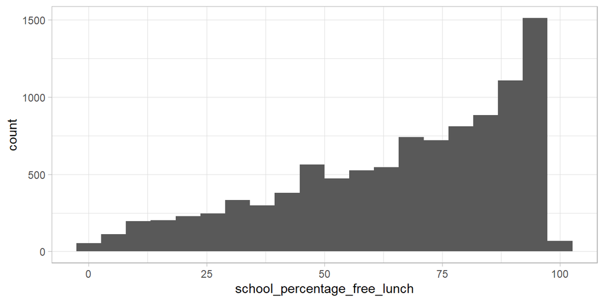

```r
df %>% ggplot(aes(x = school_percentage_free_lunch)) +
  geom_histogram(bins = 20)
```

## Text analysis using quanteda

[figure not shown]

- A variety of R packages supports quantitative text analyses. We will focus on [quanteda](https://quanteda.io/), which is created and maintained by social scientists behind the Quanteda Initiative
- Besides offering a huge number of methods for preprocessing and analysis, it also includes a function to prepare our textual data for structural topic modeling

## Quanteda corpus object

- Using `corpus()`, you can create a quanteda corpus from a character vector or a data frame, which automatically includes meta data as document variables

```r
donor_corp <- corpus(df, text_field = 'project_essay',
                 docid_field = 'project_id')
docvars(donor_corp)$text <- df$project_essay # we need unprocessed texts later
ndoc(donor_corp) # no. of documents
```

```
## [1] 10000
```

## KWIC

- Before tokenization, corpus objects be used to discover [keywords in context](https://en.wikipedia.org/wiki/Key_Word_in_Context) (KWIC):

```r
kwic_donor <- kwic(donor_corp, pattern = c("ipad"),
                      window = 5) # context window
head(kwic_donor, 3)
```

```
##
##   [54bea65a2cadc0f79f367fb1b76d6cfc, 15]      is very important. The |
##   [54bea65a2cadc0f79f367fb1b76d6cfc, 29] use advanced technology. An |
##  [54bea65a2cadc0f79f367fb1b76d6cfc, 188]      computer, much less an |
##
##  iPad | will also help my students
##  iPad | would enhance my students'
##  iPad | . The use of an
```

## Tokenization

- Tokens can be created from a corpus or character vector. The documentation (`?tokens()`) illustrates several options, e.g. for the removal of punctuation

```r
donor_tokens <- tokens(donor_corp)
donor_tokens[[1]][1:20]
```

```
##  [1] "A"          "typical"    "day"        "in"         "our"
##  [6] "room"       "consists"   "of"         "a"          "lot"
## [11] "of"         "questions"  "coming"     "from"       "interested"
## [16] "minds"      "."          "Our"        "students"   "'"
```

## Basic form of tokens

- After tokenization text, some terms with similar semantic meaning might be regarded as different features (e.g. `love`, `loving`)
- One solution is the application of [stemming](https://en.wikipedia.org/wiki/Stemming), which tries to reduce words to their basic form:

```r
words <- c("love", "loving", "lovingly", "loved", "lover", "lovely")
char_wordstem(words, 'english')
```

```
## [1] "love"  "love"  "love"  "love"  "lover" "love"
```

## To stem or not to stem?

- In the context of topic modeling, a [recent study](https://www.transacl.org/ojs/index.php/tacl/article/view/868/196) suggests that stemmers produce no meaningful improvement (for the English language)
- Ultimately, whether stemming generates useful features or not varies by use case
- An alternative that we won’t cover in this course is [lemmatization](https://en.wikipedia.org/wiki/Lemmatisation), available via packages likes [spacyr](https://cran.r-project.org/web/packages/spacyr/index.html) and [udpipe](https://cran.r-project.org/web/packages/udpipe/index.html)